# Google Trends Prediction Performance

Basira Shirzad

’2020-06-25 19:14:58

# Setup

Load some packages to help us model our data

```r
library(tidyverse)
library(scales)
library(modelr)
library(lubridate)
library(broom)

# set plot theme
theme_set(theme_bw())
knitr::opts_chunk$set(echo = TRUE)
```

# Author’s Unadjusted Data

Load and preview the author’s unadjusted data

Author’s Data: http://jakehofman.com/tmp/Autos.zip

```r
# Load the merged.csv file that contains the unadjusted data that the author used in the article
motor_vehicles <- read_csv("merged.csv")

# Add in the columns that compute the lag by month and year
motor_vehicles <- motor_vehicles %>% mutate(lag_month_sales = lag(sales, 1), lag_year_sales = lag(sales, 12))

# Preview of the author's unadjusted data
head(motor_vehicles)
```

| Period | sales | suvs | insurance | lag_month_sales | lag_year_sales |
| --- | --- | --- | --- | --- | --- |
| 2004-01-01 | 61287 | 0.00 | 0.00 | NA | NA |
| 2004-02-01 | 65381 | -0.12 | -0.01 | 61287 | NA |
| 2004-03-01 | 78843 | -0.05 | -0.09 | 65381 | NA |
| 2004-04-01 | 73422 | -0.12 | -0.08 | 78843 | NA |
| 2004-05-01 | 77662 | -0.07 | -0.07 | 73422 | NA |
| 2004-06-01 | 75516 | -0.12 | 0.01 | 77662 | NA |

> In-sample fit on the author’s unadjusted data

Baseline AR-1 model

```r
# Compute the baseline model using the author's unadjusted data
base_line <- lm(log(sales) ~ log(lag_month_sales)+ log(lag_year_sales), data=motor_vehicles)

# Preview of baseline model results
tidy(base_line)
```

| term | estimate | std.error | statistic | p.value |
| --- | --- | --- | --- | --- |
| (Intercept) | 0.6726577 | 0.76355107 | 0.8809597 | 3.811171e-01 |
| log(lag_month_sales) | 0.6434541 | 0.07331977 | 8.7759962 | 3.585367e-13 |
| log(lag_year_sales) | 0.2956540 | 0.07282240 | 4.0599314 | 1.181508e-04 |

```r
glance(base_line)
```

| r.squared | adj.r.squared | sigma | statistic | p.value | df | logLik | AIC | BIC | deviance | df.residual |
| --- | --- | --- | --- | --- | --- | --- | --- | --- | --- | --- |
| 0.71852 | 0.7111126 | 0.07984857 | 97.00069 | 1.199525e-21 | 3 | 89.11532 | -170.2306 | -160.7528 | 0.4845604 | 76 |

Trendline AR-1 model (added the trends data to the model as additional features)

```r
# Compute the trendline model using the author's unadjusted data
trend_line <- lm(log(sales) ~ log(lag_month_sales) + log(lag_year_sales) + suvs + insurance, data=motor_vehicles)

# Preview of trendline model results
tidy(trend_line)
```

| term | estimate | std.error | statistic | p.value |
| --- | --- | --- | --- | --- |
| (Intercept) | -0.4579811 | 0.78438459 | -0.5838732 | 5.610812e-01 |
| log(lag_month_sales) | 0.6194657 | 0.06317672 | 9.8052841 | 5.092203e-15 |
| log(lag_year_sales) | 0.4286540 | 0.06535382 | 6.5589736 | 6.452723e-09 |
| suvs | 1.0572064 | 0.16686193 | 6.3358151 | 1.655068e-08 |
| insurance | -0.5296634 | 0.15205794 | -3.4833002 | 8.354094e-04 |

```r
glance(trend_line)
```

| r.squared | adj.r.squared | sigma | statistic | p.value | df | logLik | AIC | BIC | deviance | df.residual |
| --- | --- | --- | --- | --- | --- | --- | --- | --- | --- | --- |
| 0.8178715 | 0.8080267 | 0.06509134 | 83.07663 | 1.345828e-26 | 5 | 106.3116 | -200.6232 | -186.4065 | 0.3135294 | 74 |

Graph showing the performance of the baseline and trendline model compared to the actual results

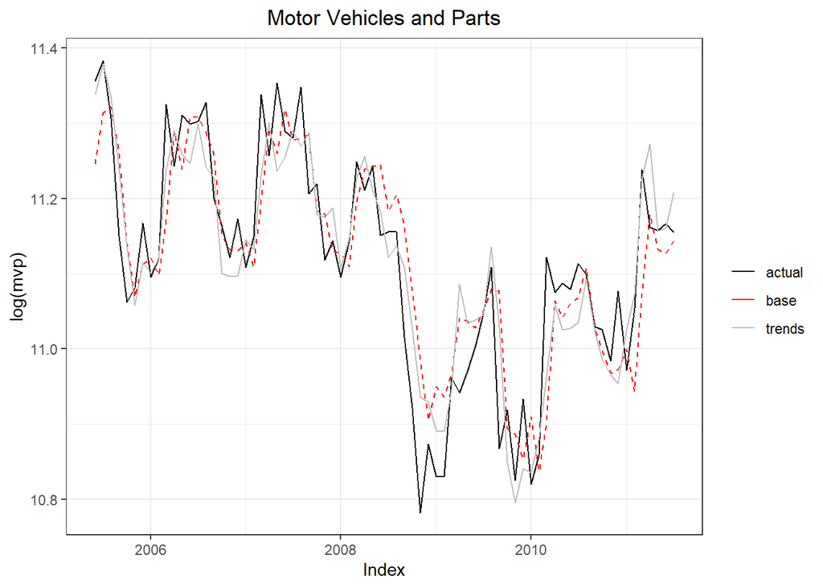

```r
# Add the predictions based off the baseline and trendline data on the author's unadjusted data
motor_vehicles <- motor_vehicles %>% add_predictions(base_line, "base_line") %>% add_predictions(trend_line, "trend_line") %>% mutate(log_sales = log(sales))

# Plot the graph of the predictions made using in-sample
motor_vehicles %>%
  filter(Period >= '2005-06-01') %>%
  ggplot() +
  geom_line(aes(x = Period, y = log_sales, color = "actual")) +
  geom_line(aes(x = Period, y = base_line, color = "base"), linetype = "dashed") +
  geom_line(aes(x = Period, y = trend_line, color = "trends")) +
  scale_colour_manual("",
                      breaks = c("actual", "base", "trends"),
                      values = c("black", "red", "grey")) +
  ggtitle("Motor Vehicles and Parts") +
  theme(plot.title = element_text(hjust = 0.5)) +
  xlab("Index") + ylab("log(mvp)")
```

> Out of Sample Forecasting on the author’s unadjusted data

Using a rolling window forecast method to estimate the data for periods 17 through 90 and then forcasting using the the lag month and lag year. The period begins from 17 so that there is at least a year long of data to create the model.

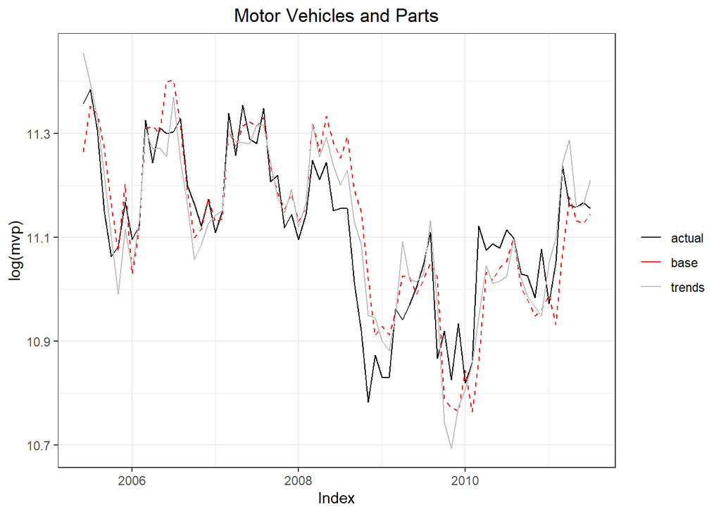

```r
# Compute the baseline model using the author's unadjusted data
base_line_out <- lm(log(sales) ~ log(lag_month_sales) + log(lag_year_sales), data=motor_vehicles[1:17,])

# Compute the trendline model using the author's unadjusted data
trend_line_out <- lm(log(sales) ~ log(lag_month_sales) + log(lag_year_sales) + suvs + insurance, data=motor_vehicles[1:17,])

# Add predictions of the first 17 rows into new dataframe called predictions
predictions <-  motor_vehicles[18,] %>% add_predictions(base_line_out, "base_pred") %>% add_predictions(trend_line_out, "trend_pred")

# Create a new model for each of the remaining rows
rows <- 18:90

for (row in rows) {

  base_line_out <- lm(log(sales) ~ log(lag_month_sales) + log(lag_year_sales), data=motor_vehicles[1:row,])

trend_line_out <- lm(log(sales) ~ log(lag_month_sales) + log(lag_year_sales) + suvs + insurance, data=motor_vehicles[1:row,])

  predictions <- add_row(predictions, add_predictions(motor_vehicles[row+1, ], base_line_out, "base_pred") %>% add_predictions(trend_line_out, "trend_pred"))
}

# Plot the graph of the predictions made using out-sample
predictions %>%
  ggplot() +
  geom_line(aes(x = Period, y = log_sales, color = "actual")) +
  geom_line(aes(x = Period, y = base_pred, color = "base"), linetype = "dashed") +
  geom_line(aes(x = Period, y = trend_pred, color = "trends")) +
  scale_colour_manual("",
                      breaks = c("actual", "base", "trends"),
                      values = c("black", "red", "grey")) +
  ggtitle("Motor Vehicles and Parts") +
  theme(plot.title = element_text(hjust = 0.5)) +
  xlab("Index") + ylab("log(mvp)")
```

> Performance Comparison on the baseline and trendline model

The Mean Absolute Error of the baseline and trendline model on the author’s unadjusted data

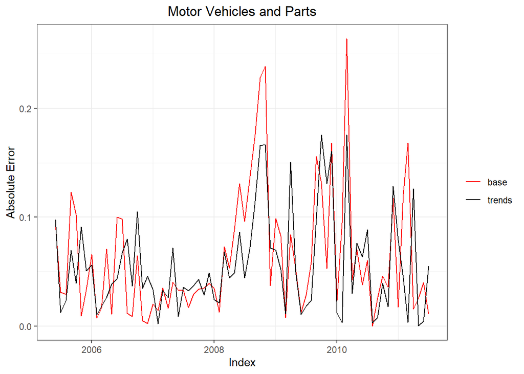

```r
# Graph of performance of baseline and trendline model
predictions %>%
  ggplot() +
  geom_line(aes(x = Period, y = abs(base_pred - log_sales), color = "base")) +
  geom_line(aes(x = Period, y = abs(trend_pred - log_sales), color = "trends")) +
  scale_colour_manual("",
                      breaks = c("base", "trends"),
                      values = c("red", "black")) +
  ggtitle("Motor Vehicles and Parts") +
  theme(plot.title = element_text(hjust = 0.5)) +
  xlab("Index") + ylab("Absolute Error")
```

```r
# Calculate the MAE during 2005-06-01 to 2011-07-01
mae_base <- mean(abs(predictions$base_pred - predictions$log_sales))
print(mae_base)
```

```
## [1] 0.06343984
```

```r
mae_trend <- mean(abs(predictions$trend_pred - predictions$log_sales))
print(mae_trend)
```

```
## [1] 0.05667658
```

```r
improvement <- ((mae_trend - mae_base) / mae_base) * 100
print(improvement)
```

```
## [1] -10.66089
```

```r
# Calculate the MAE during recession (December 2007 through June 2009)

recession <- predictions %>% filter(Period > '2007-11-01' & Period <= '2009-06-01')

mae_base_re <- mean(abs(recession$base_pred - recession$log_sales))
print(mae_base_re)
```

```
## [1] 0.08869325
```

```r
mae_trend_re <- mean(abs(recession$trend_pred - recession$log_sales))
print(mae_trend_re)
```

```
## [1] 0.06965812
```

```r
improvement_re <- ((mae_trend_re - mae_base_re) / mae_base_re) * 100
print(improvement_re)
```

```
## [1] -21.46175
```

# Raw Unadjusted Data

Load and preview the raw unadjusted data from the census and Google trends

Census Data Link: https://www.census.gov/econ/currentdata/dbsearch?program=MARTS&startYear=2004&endYear=2020&categories%5B%5D=441&dataType=SM&geoLevel=US&notAdjusted=1&submit=GET+DATA&releaseScheduleId=

Google Trends:

Trucks&SUVs: https://trends.google.com/trends/explore?cat=610&date=2004-01-01%202011-07-01&geo=US

Auto Insurance: https://trends.google.com/trends/explore?cat=467&date=2004-01-01%202011-07-01&geo=US

```r
# Load the unadjusted census data
motor_vehicles_raw <- read_csv('auto_census.csv')

# Modify the data frame so that the Period column is in proper date form
motor_vehicles_raw <- motor_vehicles_raw %>% mutate(date = paste(Period, "-01", sep="")) %>% mutate(new_date = as.Date(date, format="%b-%y-%d")) %>% select(Period = new_date, sales = Value)

# Load the Google's trend data on Trucks & SUVs
truck_suv_short <- read_csv('Truck_Suv_short.csv')

# Modify the data frame so that the Period column is in proper date form
truck_suv_short <- truck_suv_short %>% mutate(date = paste(Period, "-01", sep="")) %>% mutate(new_date = as.Date(date, format="%Y-%m-%d")) %>% select(Period = new_date, suvs)

# Load the Google's trend data on Auto Insurance
auto_insurance_short <- read_csv('Auto_Insurance_short.csv')

# Modify the data frame so that the Period column is in proper date form
auto_insurance_short <- auto_insurance_short %>% mutate(date = paste(Period, "-01", sep="")) %>% mutate(new_date = as.Date(date, format="%Y-%m-%d")) %>% select(Period = new_date, insurance)

# Create a temp to hold the inner join of the census and Truck & SUVs data
temp <- inner_join(motor_vehicles_raw, truck_suv_short, by = c("Period" = "Period"))

# Join the temp to the Auto Insurance data
motor_vehicles_raw <- inner_join(temp, auto_insurance_short, by = c("Period" = "Period"))

# Add in the columns that compute the lag by month and year
motor_vehicles_raw <- motor_vehicles_raw %>% mutate(lag_month_sales = lag(sales, 1), lag_year_sales = lag(sales, 12))

# Preview of the raw unadjusted data
head(motor_vehicles_raw)
```

| Period | sales | suvs | insurance | lag_month_sales | lag_year_sales |
| --- | --- | --- | --- | --- | --- |
| 2004-01-01 | 61146 | 96 | 93 | NA | NA |
| 2004-02-01 | 65230 | 96 | 90 | 61146 | NA |
| 2004-03-01 | 78662 | 93 | 87 | 65230 | NA |
| 2004-04-01 | 73252 | 94 | 91 | 78662 | NA |
| 2004-05-01 | 77491 | 91 | 86 | 73252 | NA |
| 2004-06-01 | 75355 | 94 | 97 | 77491 | NA |

> In-sample fit on the raw unadjusted data

Baseline AR-1 model

```r
# Compute the baseline model using the raw unadjusted data
base_line <- lm(log(sales) ~ log(lag_month_sales)+ log(lag_year_sales), data=motor_vehicles_raw)

# Preview of baseline model results
tidy(base_line)
```

| term | estimate | std.error | statistic | p.value |
| --- | --- | --- | --- | --- |
| (Intercept) | 0.6677571 | 0.75960466 | 0.879085 | 3.821262e-01 |
| log(lag_month_sales) | 0.6509889 | 0.07282435 | 8.939165 | 1.745591e-13 |
| log(lag_year_sales) | 0.2885261 | 0.07224555 | 3.993687 | 1.489789e-04 |

```r
glance(base_line)
```

| r.squared | adj.r.squared | sigma | statistic | p.value | df | logLik | AIC | BIC | deviance | df.residual |
| --- | --- | --- | --- | --- | --- | --- | --- | --- | --- | --- |
| 0.7212228 | 0.7138866 | 0.08014635 | 98.30958 | 8.313308e-22 | 3 | 88.82125 | -169.6425 | -160.1647 | 0.4881813 | 76 |

Trendline AR-1 model (added the trends data to the model as additional features)

```r
# Compute the trendline model using the raw unadjusted data
trend_line <- lm(log(sales) ~ log(lag_month_sales) + log(lag_year_sales) + suvs + insurance, data=motor_vehicles_raw)

# Preview of trendline model results
tidy(trend_line)
```

| term | estimate | std.error | statistic | p.value |
| --- | --- | --- | --- | --- |
| (Intercept) | 1.158411544 | 1.017255824 | 1.138761 | 2.584759e-01 |
| log(lag_month_sales) | 0.556442298 | 0.078681207 | 7.072112 | 7.211313e-10 |
| log(lag_year_sales) | 0.305576155 | 0.070880097 | 4.311170 | 4.937454e-05 |
| suvs | 0.011461201 | 0.002669861 | 4.292808 | 5.275596e-05 |
| insurance | -0.006890429 | 0.002111847 | -3.262750 | 1.670922e-03 |

```r
glance(trend_line)
```

| r.squared | adj.r.squared | sigma | statistic | p.value | df | logLik | AIC | BIC | deviance | df.residual |
| --- | --- | --- | --- | --- | --- | --- | --- | --- | --- | --- |
| 0.7850157 | 0.7733949 | 0.07132626 | 67.55279 | 5.981785e-24 | 5 | 99.08524 | -186.1705 | -171.9538 | 0.3764702 | 74 |

Graph showing the performance of the baseline and trendline model compared to the actual results

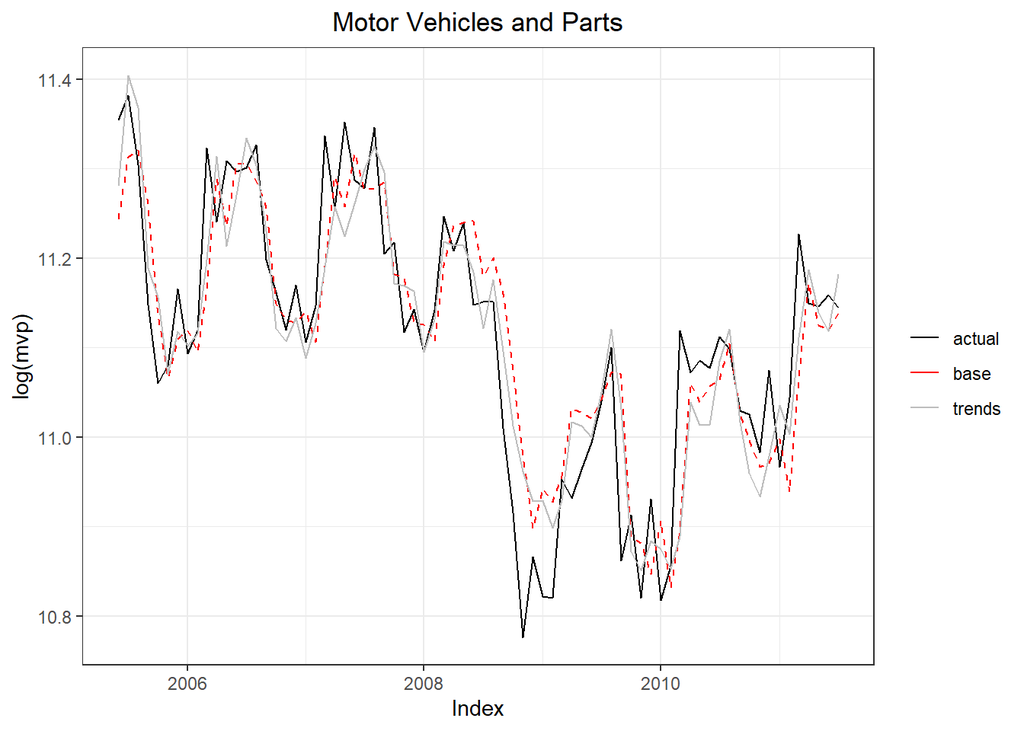

```r
# Add the predictions based off the baseline and trendline data on the raw unadjusted data
motor_vehicles_raw <- motor_vehicles_raw %>% add_predictions(base_line, "base_line") %>% add_predictions(trend_line, "trend_line") %>% mutate(log_sales = log(sales))

# Plot the graph of the predictions made using in-sample
motor_vehicles_raw %>%
  filter(Period >= '2005-06-01') %>%
  ggplot() +
  geom_line(aes(x = Period, y = log_sales, color = "actual")) +
  geom_line(aes(x = Period, y = base_line, colour = "base"), linetype = "dashed") +
  geom_line(aes(x = Period, y = trend_line, color = "trends")) +
  scale_colour_manual("",
                      breaks = c("actual", "base", "trends"),
                      values = c("black", "red", "grey")) +
  ggtitle("Motor Vehicles and Parts") +
  theme(plot.title = element_text(hjust = 0.5)) +
  xlab("Index") + ylab("log(mvp)")
```

> Out of Sample Forecasting on the raw unadjusted data

Using a rolling window forecast method to estimate the data for periods 17 through 90 and then forcasting using the the lag month and lag year. The period begins from 17 so that there is at least a year long of data to create the model.

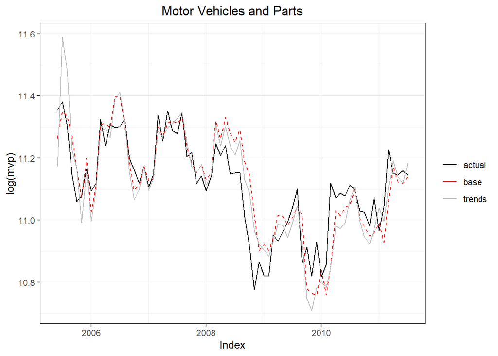

```r
# Compute the baseline model using the raw unadjusted data
base_line_out <- lm(log(sales) ~ log(lag_month_sales) + log(lag_year_sales), data=motor_vehicles_raw[1:17,])

# Compute the trendline model using the raw unadjusted data
trend_line_out <- lm(log(sales) ~ log(lag_month_sales) + log(lag_year_sales) + suvs + insurance, data=motor_vehicles_raw[1:17,])

# Add predictions of the first 17 rows into new dataframe called predictions
predictions <-  motor_vehicles_raw[18,] %>% add_predictions(base_line_out, "base_pred") %>% add_predictions(trend_line_out, "trend_pred")

# Create a new model for each of the remaining rows
rows <- 18:90

for (row in rows) {

  base_line_out <- lm(log(sales) ~ log(lag_month_sales) + log(lag_year_sales), data=motor_vehicles_raw[1:row,])

  trend_line_out <- lm(log(sales) ~ log(lag_month_sales) + log(lag_year_sales) + suvs + insurance, data=motor_vehicles_raw[1:row,])

  predictions <- add_row(predictions, add_predictions(motor_vehicles_raw[row+1, ], base_line_out, "base_pred") %>% add_predictions(trend_line_out, "trend_pred"))
}

# Plot the graph of the predictions made using out-sample
predictions %>%
  ggplot() +
  geom_line(aes(x = Period, y = log(sales), color = "actual")) +
  geom_line(aes(x = Period, y = base_pred, color = "base"), linetype = "dashed") +
  geom_line(aes(x = Period, y = trend_pred, color = "trends")) +
  scale_colour_manual("",
                      breaks = c("actual", "base", "trends"),
                      values = c("black", "red", "grey")) +
  ggtitle("Motor Vehicles and Parts") +
  theme(plot.title = element_text(hjust = 0.5)) +
  xlab("Index") + ylab("log(mvp)")
```

> Performance Comparison of baseline and trendline model

The Mean Absolute Error of the baseline and trendline model on the raw unadjusted data

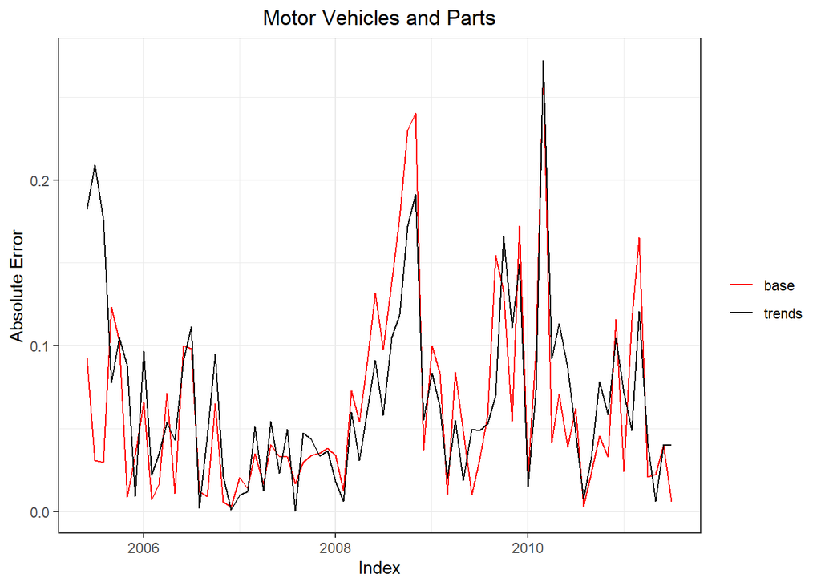

```r
# Graph of performance of baseline and trendline model
predictions %>%
  ggplot() +
  geom_line(aes(x = Period, y = abs(base_pred - log_sales), color = "base")) +
  geom_line(aes(x = Period, y = abs(trend_pred - log_sales), color = "trends")) +
  scale_colour_manual("",
                      breaks = c("base", "trends"),
                      values = c("red", "black")) +
  ggtitle("Motor Vehicles and Parts") +
  theme(plot.title = element_text(hjust = 0.5)) +
  xlab("Index") + ylab("Absolute Error")
```

```r
# Calculate the MAE during 2005-06-01 to 2011-07-01
mae_base <- mean(abs(predictions$base_pred - predictions$log_sales))
print(mae_base)
```

```
## [1] 0.06365923
```

```r
mae_trend <- mean(abs(predictions$trend_pred - predictions$log_sales))
print(mae_trend)
```

```
## [1] 0.0682912
```

```r
improvement <- ((mae_trend - mae_base) / mae_base) * 100
print(improvement)
```

```
## [1] 7.276191
```

```r
# Calculate the MAE during recession (December 2007 through June 2009)

recession <- predictions %>% filter(Period > '2007-11-01' & Period <= '2009-06-01')

mae_base_re <- mean(abs(recession$base_pred - recession$log_sales))
print(mae_base_re)
```

```
## [1] 0.08903226
```

```r
mae_trend_re <- mean(abs(recession$trend_pred - recession$log_sales))
print(mae_trend_re)
```

```
## [1] 0.06821008
```

```r
improvement_re <- ((mae_trend_re - mae_base_re) / mae_base_re) * 100
print(improvement_re)
```

```
## [1] -23.38723
```

# Extension of Raw Unadjusted Data

Load and preview the raw unadjusted data from the census and Google trends from the year: 2004 to 2020

Census Data Link: https://www.census.gov/econ/currentdata/dbsearch?program=MARTS&startYear=2004&endYear=2020&categories%5B%5D=441&dataType=SM&geoLevel=US&notAdjusted=1&submit=GET+DATA&releaseScheduleId=

Google Trends:

Trucks&SUVs: https://trends.google.com/trends/explore?cat=610&date=all&geo=US

Auto Insurance: https://trends.google.com/trends/explore?cat=467&date=all&geo=US

```r
# Load the unadjusted census data
motor_vehicles_ext <- read_csv('auto_census.csv')

# Modify the data frame so that the Period column is in proper date form
motor_vehicles_ext <- motor_vehicles_ext %>% mutate(date = paste(Period, "-01", sep="")) %>% mutate(new_date = as.Date(date, format="%b-%y-%d")) %>% select(Period = new_date, sales = Value)

# Load the Google's trend data on Trucks & SUVs
truck_suv_ext <- read_csv('Truck_Suv_ext.csv')

# Modify the data frame so that the Period column is in proper date form
truck_suv_ext <- truck_suv_ext %>% mutate(date = paste(Period, "-01", sep="")) %>% mutate(new_date = as.Date(date, format="%Y-%m-%d")) %>% select(Period = new_date, suvs)

# Load the Google's trend data on Auto Insurance
auto_insurance_ext <- read_csv('Auto_Insurance_ext.csv')

# Modify the data frame so that the Period column is in proper date form
auto_insurance_ext <- auto_insurance_ext %>% mutate(date = paste(Period, "-01", sep="")) %>% mutate(new_date = as.Date(date, format="%Y-%m-%d")) %>% select(Period = new_date, insurance)

# Create a temp to hold the inner join of the census and Truck & SUVs data
temp <- inner_join(motor_vehicles_ext, truck_suv_ext, by = c("Period" = "Period"))

# Join the temp to the Auto Insurance data
motor_vehicles_ext <- inner_join(temp, auto_insurance_ext, by = c("Period" = "Period"))

# Add in the columns that compute the lag by month and year
motor_vehicles_ext <- motor_vehicles_ext %>% mutate(lag_month_sales = lag(sales, 1), lag_year_sales = lag(sales, 12)) %>% filter(!is.na(sales))

# Preview of the raw unadjusted extension data
head(motor_vehicles_ext)
```

| Period | sales | suvs | insurance | lag_month_sales | lag_year_sales |
| --- | --- | --- | --- | --- | --- |
| 2004-01-01 | 61146 | 95 | 92 | NA | NA |
| 2004-02-01 | 65230 | 91 | 85 | 61146 | NA |
| 2004-03-01 | 78662 | 89 | 87 | 65230 | NA |
| 2004-04-01 | 73252 | 94 | 87 | 78662 | NA |
| 2004-05-01 | 77491 | 94 | 86 | 73252 | NA |
| 2004-06-01 | 75355 | 94 | 94 | 77491 | NA |

> In-sample fit on the raw unadjusted extension data

Baseline AR-1 model

```r
# Compute the baseline model using the raw unadjusted extension data
base_line <- lm(log(sales) ~ log(lag_month_sales)+ log(lag_year_sales), data=motor_vehicles_ext)

# Preview of baseline model results
tidy(base_line)
```

| term | estimate | std.error | statistic | p.value |
| --- | --- | --- | --- | --- |
| (Intercept) | -0.03950362 | 0.33362698 | -0.1184065 | 9.058761e-01 |
| log(lag_month_sales) | 0.54397565 | 0.04544416 | 11.9701997 | 9.926055e-25 |
| log(lag_year_sales) | 0.46044120 | 0.04742276 | 9.7092865 | 3.202104e-18 |

```r
glance(base_line)
```

| r.squared | adj.r.squared | sigma | statistic | p.value | df | logLik | AIC | BIC | deviance | df.residual |
| --- | --- | --- | --- | --- | --- | --- | --- | --- | --- | --- |
| 0.8644859 | 0.8629968 | 0.07389398 | 580.517 | 1.024663e-79 | 3 | 220.9566 | -433.9132 | -421.0317 | 0.9937784 | 182 |

Trendline AR-1 model (added the trends data to the model as additional features)

```r
# Compute the trendline model using the raw unadjusted extension data
trend_line <- lm(log(sales) ~ log(lag_month_sales) + log(lag_year_sales) + suvs + insurance, data=motor_vehicles_ext)

# Preview of trendline model results
tidy(trend_line)
```

| term | estimate | std.error | statistic | p.value |
| --- | --- | --- | --- | --- |
| (Intercept) | 1.153154757 | 0.5087792528 | 2.266513 | 2.460996e-02 |
| log(lag_month_sales) | 0.488939562 | 0.0478742572 | 10.212995 | 1.322201e-19 |
| log(lag_year_sales) | 0.400940068 | 0.0508568492 | 7.883699 | 2.943362e-13 |
| suvs | 0.002506443 | 0.0008187123 | 3.061445 | 2.540276e-03 |
| insurance | -0.001591279 | 0.0006105592 | -2.606265 | 9.920309e-03 |

```r
glance(trend_line)
```

| r.squared | adj.r.squared | sigma | statistic | p.value | df | logLik | AIC | BIC | deviance | df.residual |
| --- | --- | --- | --- | --- | --- | --- | --- | --- | --- | --- |
| 0.8715223 | 0.8686672 | 0.07234861 | 305.2553 | 4.949069e-79 | 5 | 225.8887 | -439.7774 | -420.4553 | 0.9421779 | 180 |

Graph showing the performance of the baseline and trendline model compared to the actual results

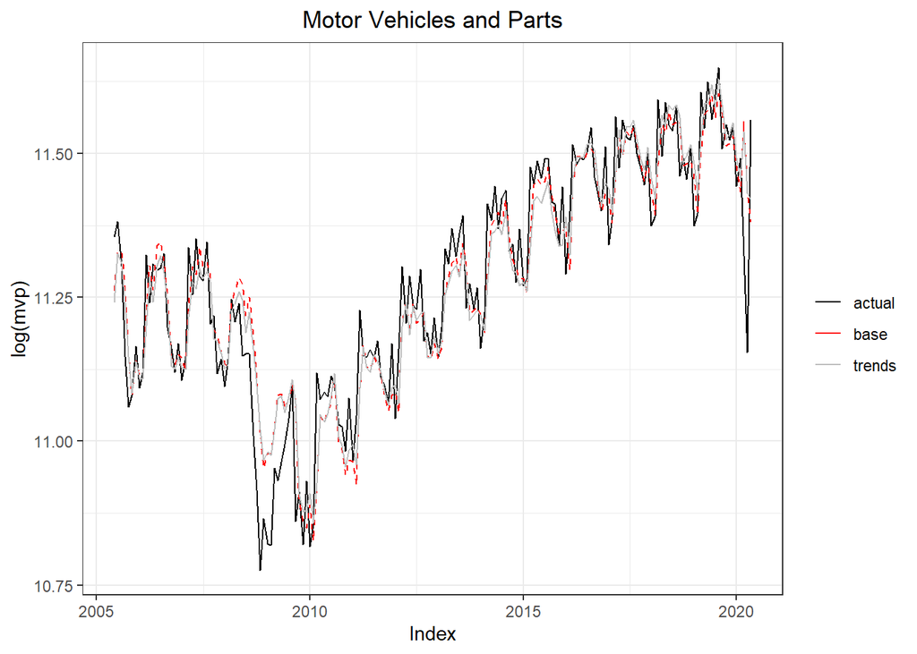

```r
# Add the predictions based off the baseline and trendline data on the raw unadjusted extension data
motor_vehicles_ext <- motor_vehicles_ext %>% add_predictions(base_line, "base_line") %>% add_predictions(trend_line, "trend_line") %>% mutate(log_sales = log(sales))

# Plot the graph of the predictions made using in-sample
motor_vehicles_ext %>%
  filter(Period >= '2005-06-01') %>%
  ggplot() +
  geom_line(aes(x = Period, y = log_sales, color = "actual")) +
  geom_line(aes(x = Period, y = base_line, colour = "base"), linetype = "dashed") +
  geom_line(aes(x = Period, y = trend_line, color = "trends")) +
  scale_colour_manual("",
                      breaks = c("actual", "base", "trends"),
                      values = c("black", "red", "grey")) +
  ggtitle("Motor Vehicles and Parts") +
  theme(plot.title = element_text(hjust = 0.5)) +
  xlab("Index") + ylab("log(mvp)")
```

> Out of Sample Forecasting on the raw unadjusted extension data

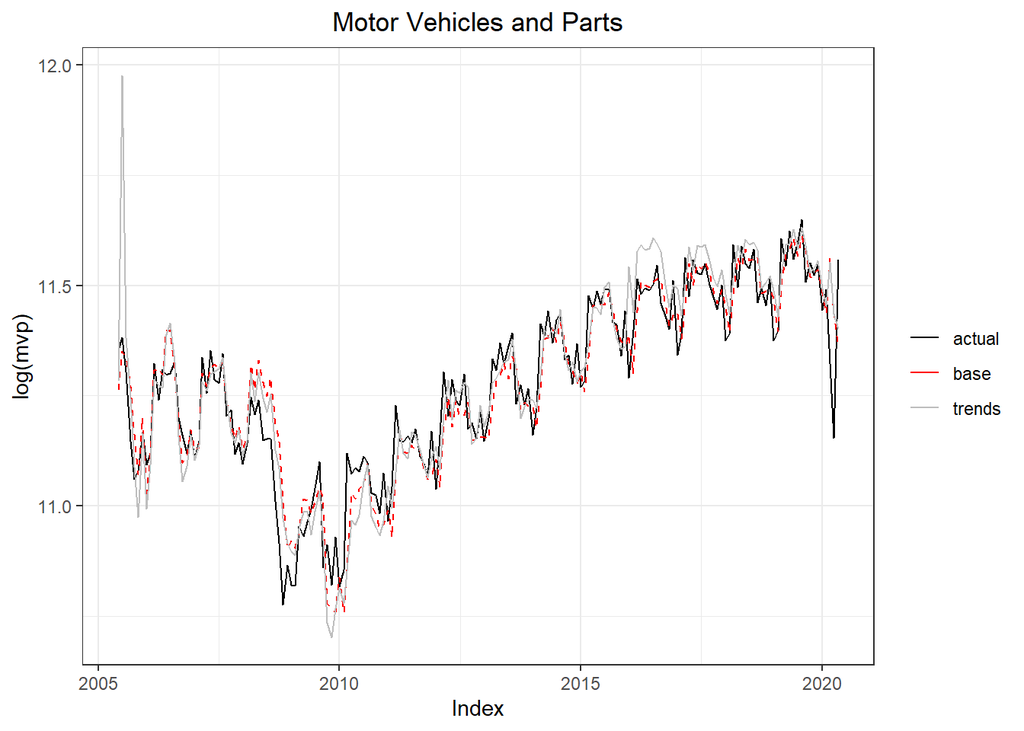

```r
# Compute the baseline model using the raw unadjusted extension data
base_line_out <- lm(log(sales) ~ log(lag_month_sales) + log(lag_year_sales), data=motor_vehicles_ext[1:17,])

# Compute the trendline model using the raw unadjusted extension data
trend_line_out <- lm(log(sales) ~ log(lag_month_sales) + log(lag_year_sales) + suvs + insurance, data=motor_vehicles_ext[1:17,])

# Add predictions of the first 17 rows into new dataframe called predictions
predictions <-  motor_vehicles_ext[18,] %>% add_predictions(base_line_out, "base_pred") %>% add_predictions(trend_line_out, "trend_pred")

# Create a new model for each of the remaining rows
rows <- 18:196

for (row in rows) {

  base_line_out <- lm(log(sales) ~ log(lag_month_sales) + log(lag_year_sales), data=motor_vehicles_ext[1:row,])

  trend_line_out <- lm(log(sales) ~ log(lag_month_sales) + log(lag_year_sales) + suvs + insurance, data=motor_vehicles_ext[1:row,])

  predictions <- add_row(predictions, add_predictions(motor_vehicles_ext[row+1, ], base_line_out, "base_pred") %>% add_predictions(trend_line_out, "trend_pred"))
}

# Plot the graph of the predictions made using out-sample
predictions %>%
  ggplot() +
  geom_line(aes(x = Period, y = log(sales), color = "actual")) +
  geom_line(aes(x = Period, y = base_pred, color = "base"), linetype = "dashed") +
  geom_line(aes(x = Period, y = trend_pred, color = "trends")) +
  scale_colour_manual("",
                      breaks = c("actual", "base", "trends"),
                      values = c("black", "red", "grey")) +
  ggtitle("Motor Vehicles and Parts") +
  theme(plot.title = element_text(hjust = 0.5)) +
  xlab("Index") + ylab("log(mvp)")
```

> Performance Comparison of baseline and trendline model

The Mean Absolute Error of the baseline and trendline model on the raw unadjusted extension data

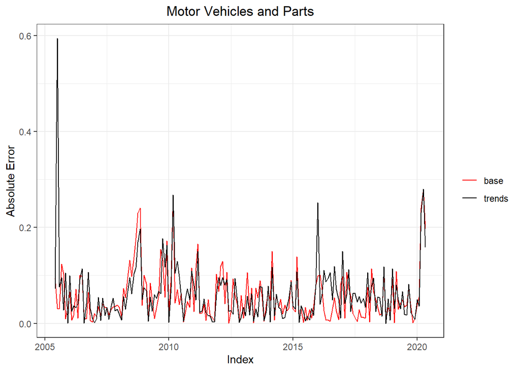

```r
# Graph of performance of baseline and trendline model
predictions %>%
  ggplot() +
  geom_line(aes(x = Period, y = abs(base_pred - log_sales), color = "base")) +
  geom_line(aes(x = Period, y = abs(trend_pred - log_sales), color = "trends")) +
  scale_colour_manual("",
                      breaks = c("base", "trends"),
                      values = c("red", "black")) +
  ggtitle("Motor Vehicles and Parts") +
  theme(plot.title = element_text(hjust = 0.5)) +
  xlab("Index") + ylab("Absolute Error")
```

```r
# Calculate the MAE during 2005-06-01 to Present
mae_base <- mean(abs(predictions$base_pred - predictions$log_sales))
print(mae_base)
```

```
## [1] 0.05615793
```

```r
mae_trend <- mean(abs(predictions$trend_pred - predictions$log_sales))
print(mae_trend)
```

```
## [1] 0.06160114
```

```r
improvement <- ((mae_trend - mae_base) / mae_base) * 100
print(improvement)
```

```
## [1] 9.692692
```

```r
# Calculate the MAE during recession (December 2007 through June 2009)

recession <- predictions %>% filter(Period > '2007-11-01' & Period <= '2009-06-01')

mae_base_re <- mean(abs(recession$base_pred - recession$log_sales))
print(mae_base_re)
```

```
## [1] 0.08903226
```

```r
mae_trend_re <- mean(abs(recession$trend_pred - recession$log_sales))
print(mae_trend_re)
```

```
## [1] 0.06762051
```

```r
improvement_re <- ((mae_trend_re - mae_base_re) / mae_base_re) * 100
print(improvement_re)
```

```
## [1] -24.04943
```

```r
# Calculate the MAE during covid-19 outbreak (December 2007 through June 2009)

covid_outbreak <- predictions %>% filter(Period >= '2020-03-01' & Period <= '2020-06-01')

mae_base_cv <- mean(abs(covid_outbreak$base_pred - covid_outbreak$log_sales))
print(mae_base_cv)
```

```
## [1] 0.239014
```

```r
mae_trend_cv <- mean(abs(covid_outbreak$trend_pred - covid_outbreak$log_sales))
print(mae_trend_cv)
```

```
## [1] 0.2230108
```

```r
improvement_cv <- ((mae_trend_cv - mae_base_cv) / mae_base_cv) * 100
print(improvement_cv)
```

```
## [1] -6.695535
```